# Starting with Flexdashboard

Miguel Ángel Daza

April 9, 2019

## INDEX

### - Structure of a dashboard.

### - Static dashboard.

### - Dynamic dashboard.

> Note: The content of this presentation has been obtained from the websites [R Markdown from RStudio](https://rmarkdown.rstudio.com/lesson-12.html) , [Flexdashboard for R](https://rmarkdown.rstudio.com/flexdashboard/index.html) and [R Markdown: The Definitive Guide](https://bookdown.org/yihui/rmarkdown/dashboards.html).

## FLEXDASHBOARD

Dashboards are a useful way to communicate large amounts of information visually and quickly. Create one with the **flexdashboard::flex_dashboard** output format, as in the **.Rmd** file.

Flexdashboard makes easy to organize your content into a visual layout:

- Each Level 1 Header (#) begins a new **page** in the dashboard.
- Each Level 2 Header (##) begins a new **column**.
- Each Level 3 Header (###) begins a new **box**.

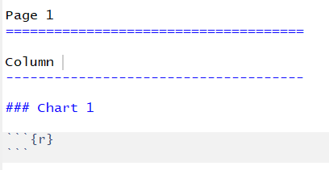

Another way to indicate the 3 levels

## FEATURES:

- Use R Markdown to publish a group of related data visualizations as a dashboard.
- Support for a wide variety of components including html widgets; base, lattice, and grid graphics; tabular data; gauges and value boxes; and text annotations.
- Flexible and easy to specify row and column-based layouts. Components are intelligently re-sized to fill the browser and adapted for display on mobile devices.
- Storyboard layouts for presenting sequences of visualizations and related comments.
- Optionally use Shiny to drive visualizations dynamically.

## LAYOUT

There are many examples of layouts in [Flexdashboard for R](https://rmarkdown.rstudio.com/flexdashboard/layouts.html#overview).

Many of them must be added to the *Rmarkdown yaml-header*.

One could set the design:  
- in rows **orientation: rows**,  
- or in columns **orientation: columns**.

Furthermore, you can decide if you want: - to fit the content in a page, - or to use scrolling websites **vertical_layout: scroll**.

Other possibility is to create a storyboard **storyboard: true**.

For Shiny features, **runtime: shiny** must be added. Then, we can include a sidebar by **Sidebar {.sidebar}**: - global at the level of the **page**, - or local at the level of the **row** or **column**.

Also, it is possible to create tabs: - in rows, when define a new one, **Row {.tabset .tabset-fade}**, - in columns, when define a new one, **Column {.tabset}**.

## - STRUCTURE OF DASHBOARD

- Template of RStudio…(view)
- Template by rows…(view)
- Template with Tabs…(view)
- Template with Pages…(view)
- Template with Storyboard…(view)
- Template with Shiny…(view)

> Note: All of this examples has been obtained from the website [Flexdasboard for R](https://rmarkdown.rstudio.com/flexdashboard/index.html).

## VALUE BOXES

If you add the next R code, a value box is displayed.

```r
### Primary
NumsWifi = 10
valueBox(NumsWifi, icon = "fa-wifi", color="primary")
```

[figure not shown]

More examples of value boxes

## GAUGES

The next code produces a gauge (Shiny is needed, **runtime: shiny**).

```r
### Contact Rate
gauge(91, min = 0, max = 100, symbol = '%', gaugeSectors(
  success = c(80, 100), warning = c(40, 79), danger = c(0, 39)
))
```

There are three colors that correspond to the text:  
- green -> **success**,  
- orange -> **warning**,  
- Red -> **danger**.

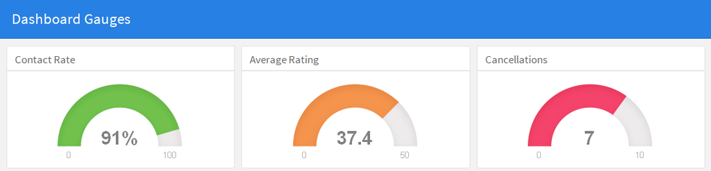

More examples of gauges

## - STATIC DASHBOARD

- Ex 1 page 4 boxes…(view)
- Ex 4 pages + barplot…(view)
- Ex 4 pages + ggplot…(view)
- Ex 5 pages + alluvial Gray…(view)
- Ex 6 pages + alluvial Color…(view)
- Ex 7 pages + heatmap…(view)

> Note: All of this examples has been obtained using data file LogFile_corrected.csv

## SHINY (use)

Using Shiny with flexdashboard turns a **static** R Markdown report into an **Interactive** Document.  
It is important to note that **interactive** documents need to be deployed to **a Shiny Server** to be shared broadly (whereas static R Markdown documents are standalone web pages that can be attached to emails or served from any standard web server).

> Note that the [**shinydashboard package**](https://rstudio.github.io/shinydashboard/) provides another way to create dashboards with Shiny.

## SHINY (How to Start)

The steps required to add Shiny components to a flexdashboard are as follows:

- Add **runtime: shiny** to the options declared at the top of the document (YAML front matter).
- Add the **{.sidebar}** attribute to the first column of the dashboard to make it a host for Shiny input controls (note this step is not strictly required, but many Shiny based dashboards will demand).
- Add **Shiny inputs** and **outputs** as appropriate.
- When including plots, be sure to wrap them in a call to **renderPlot**. This is important not only for dynamically responding to changes but also to ensure that they are **automatically re-sized** when their container changes.

## SHINY (Render functions)

You can use some of these render functions:

```r
renderDataTable({ })

renderGauge({ })

renderImage({ })

renderPlot({ })

renderPlotly({ })

renderPrint({ })

renderSankeyNetwork({ })

renderTable({ })

renderText({ })

renderUI({ })

renderValueBox({ })
```

## - DYNAMIC DASHBOARD

- Ex 8 pages + Shiny…(view)
- Ex 2 pages + Shiny + Select Data…(view)
- Ex 2 pages + Shiny + Select Data + heatmap…(view)

> Note: All of this examples has been obtained using the data file LogFile_corrected.csv

## Thanks!!!

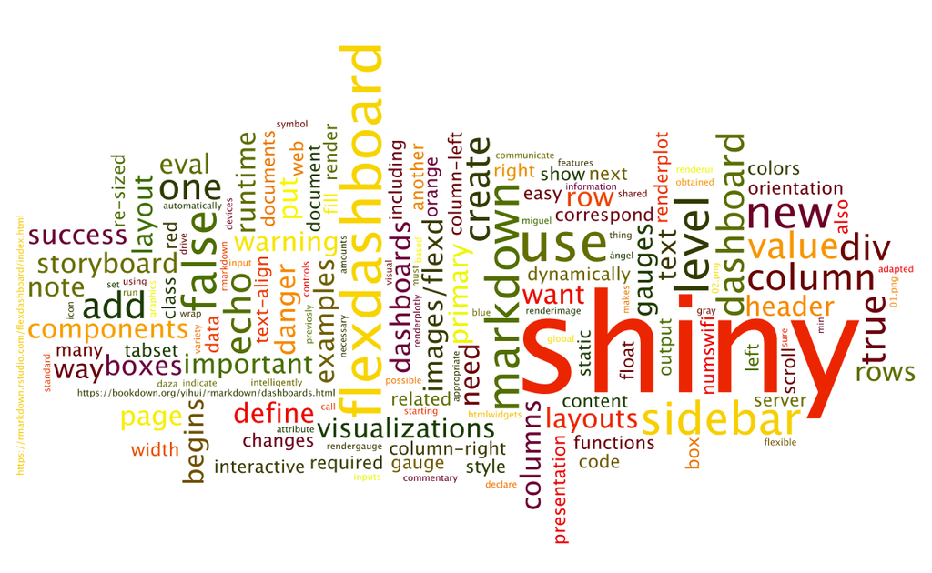